# regression_modeling_chefs_compass

## Linear Modeling Case Study | Chef’s Compass

##### February 08, 2026

#### DAT-5390 | Computational Data Analytics with Python

##### By: **Renan Peres** | https://github.com/renan-peres/

[figure not shown]

Chef’s Compass

## **Executive Summary**

Chef’s Compass is a meal kit delivery service for busy professionals, offering daily-prepared gourmet meals (under 30 minutes to finish) with disposable cookware. Customers order via website or app and can subscribe to weekly plans (3 meals/week at 10% off, or 5 meals/week at 15% off). The dataset covers ~2,000 customers with consistent first-year ordering behavior.

**This analysis predicts customer `REVENUE` using regression modeling.**

> **Key Findings**: Of 14 model-target combinations (7 model types x 2 targets), the **Gradient Boosting model on `log_REVENUE`** performs best (Test R-squared ~0.82 with a train-test gap of 0.021). The engineered feature `ENGAGEMENT_X_MEALS` is the top predictor (~20% of total importance). Email domain type shows no relationship with REVENUE (ANOVA p = 0.80).

> **Business Takeaway**: Focus retention on customers below 40 total meals (Reichheld & Sasser, 1990), invest in engagement content that drives composite engagement features (Kumar et al., 2010), and introduce loyalty tiers at 50/100/150 meals to incentivize progression up the value curve (Uncles et al., 2003).

## **Imports**

### **Libraries/Functions**

```python
# data manipulation
import pandas            as pd
import numpy             as np

# visualization
import matplotlib.pyplot as plt
import seaborn           as sns

# modeling
import sklearn.linear_model                                        # linear regression
import statsmodels.api   as sm                                     # statistical modeling
from scipy                     import stats                        # statistical testing
from sklearn.model_selection   import train_test_split             # train-test split
from sklearn.linear_model      import Lasso                        # L1 regularization
from sklearn.linear_model      import Ridge                        # L2 regularization
from sklearn.linear_model      import SGDRegressor                 # L1 + L2 (elastic net)
from sklearn.neighbors         import KNeighborsRegressor          # k-nearest neighbors
from sklearn.ensemble          import RandomForestRegressor        # random forest
from sklearn.ensemble          import GradientBoostingRegressor    # gradient boosting
from sklearn.preprocessing     import StandardScaler               # feature scaling
from sklearn.base              import clone                        # model cloning


# pandas display options
pd.set_option('display.max_rows', 500)
pd.set_option('display.max_columns', 500)
pd.set_option('display.width', 1000)


# suppress warnings
import warnings
warnings.filterwarnings(action = 'ignore')
```

### **Dataset**

```python
file = 'chefs_compass.xlsx'

chef_df = pd.read_excel(io       = file,
                        engine   = 'openpyxl',
                        usecols  = lambda x: x != 'OBS')  # drop customer ID
```

### **User-Defined Functions (UDFs)**

```python
########################################
# impute_outliers_iqr
########################################
def impute_outliers_iqr(data, column):
    """Replace values outside 1.5*IQR with the column median."""
    Q1     = data[column].quantile(0.25)
    Q3     = data[column].quantile(0.75)
    IQR    = Q3 - Q1
    lower  = Q1 - 1.5 * IQR
    upper  = Q3 + 1.5 * IQR
    median = data[column].median()

    data[column] = data[column].apply(
        lambda x: median if (x < lower or x > upper) else x
    )
    return data


########################################
# plot_feature_importances
########################################
def plot_feature_importances(model, train, title=None, export=False, top_n=None):
    """Plot horizontal bar chart of non-zero feature importances from a tree-based model."""
    importances = model.feature_importances_
    cols        = np.array(train.columns)

    # keep only features with non-zero importance
    mask        = importances > 0
    importances = importances[mask]
    cols        = cols[mask]

    # sort ascending for horizontal bar layout
    order       = np.argsort(importances)
    importances = importances[order]
    cols        = cols[order]

    if top_n is not None:
        importances = importances[-top_n:]
        cols        = cols[-top_n:]

    fig, ax = plt.subplots(figsize=(10, 8))
    ax.barh(range(len(cols)), importances, align="center")
    ax.set_yticks(range(len(cols)))
    ax.set_yticklabels(cols)
    if title is not None:
        ax.set_title(title)
    ax.set_xlabel("Feature importance")

    if export:
        plt.savefig("./analysis_images/Tree_Visual.png", bbox_inches="tight")

    plt.show()
```

## **Exploratory Data Analysis (EDA)**

### **Dataset Shape**

```python
print("Shape:", chef_df.shape)
display(chef_df.head(n = 5))
```

```
Shape: (1946, 18)
```

|  | NAME | EMAIL | TOTAL_MEALS_ORDERED | UNIQUE_MEALS_PURCH | CONTACTS_W_CUSTOMER_SERVICE | PRODUCT_CATEGORIES_VIEWED | AVG_TIME_PER_SITE_VISIT | CANCELLATIONS_AFTER_NOON | PC_LOGINS | MOBILE_LOGINS | WEEKLY_PLAN | LATE_DELIVERIES | AVG_PREP_VID_TIME | LARGEST_ORDER_SIZE | AVG_MEAN_RATING | TOTAL_PHOTOS_VIEWED | CROSS_SELL_SUCCESS | REVENUE |
| --- | --- | --- | --- | --- | --- | --- | --- | --- | --- | --- | --- | --- | --- | --- | --- | --- | --- | --- |
| 0 | Steffon Baratheon | steffon.baratheon@yahoo.com | 493 | 9 | 1 | 10 | 265.6 | 5 | 5 | 2 | 0 | 0 | 137.41 | 6 | 2.894737 | 456 | 1 | 4920.0 |
| 1 | Harlon Greyjoy | harlon.greyjoy@visa.com | 361 | 9 | 1 | 6 | 247.0 | 2 | 5 | 1 | 0 | 0 | 120.20 | 5 | 2.631579 | 680 | 0 | 6150.0 |
| 2 | Monster | monster@protonmail.com | 278 | 6 | 1 | 4 | 164.4 | 0 | 6 | 1 | 5 | 0 | 127.00 | 3 | 3.684211 | 145 | 0 | 3435.0 |
| 3 | Damon Lannister (lord) | damon.lannister.(lord)@yahoo.com | 269 | 8 | 1 | 2 | 176.0 | 5 | 5 | 2 | 0 | 0 | 129.78 | 6 | 3.157895 | 418 | 1 | 3330.0 |
| 4 | Raynald Westerling | raynald.westerling@jnj.com | 276 | 7 | 1 | 10 | 164.6 | 0 | 6 | 1 | 14 | 0 | 34.42 | 3 | 3.157895 | 174 | 1 | 3427.5 |

### **Data Types**

```python
print(f"""
Data Types (Count):
{chef_df.dtypes.value_counts()}

Data Types:
{chef_df.dtypes}
""")
```

```
Data Types (Count):
int64      12
float64     4
object      2
Name: count, dtype: int64

Data Types:
NAME                            object
EMAIL                           object
TOTAL_MEALS_ORDERED              int64
UNIQUE_MEALS_PURCH               int64
CONTACTS_W_CUSTOMER_SERVICE      int64
PRODUCT_CATEGORIES_VIEWED        int64
AVG_TIME_PER_SITE_VISIT        float64
CANCELLATIONS_AFTER_NOON         int64
PC_LOGINS                        int64
MOBILE_LOGINS                    int64
WEEKLY_PLAN                      int64
LATE_DELIVERIES                  int64
AVG_PREP_VID_TIME              float64
LARGEST_ORDER_SIZE               int64
AVG_MEAN_RATING                float64
TOTAL_PHOTOS_VIEWED              int64
CROSS_SELL_SUCCESS               int64
REVENUE                        float64
dtype: object
```

### **Missing Values**

```python
print(chef_df.isnull().sum())
```

```
NAME                           0
EMAIL                          0
TOTAL_MEALS_ORDERED            0
UNIQUE_MEALS_PURCH             0
CONTACTS_W_CUSTOMER_SERVICE    0
PRODUCT_CATEGORIES_VIEWED      0
AVG_TIME_PER_SITE_VISIT        0
CANCELLATIONS_AFTER_NOON       0
PC_LOGINS                      0
MOBILE_LOGINS                  0
WEEKLY_PLAN                    0
LATE_DELIVERIES                0
AVG_PREP_VID_TIME              0
LARGEST_ORDER_SIZE             0
AVG_MEAN_RATING                0
TOTAL_PHOTOS_VIEWED            0
CROSS_SELL_SUCCESS             0
REVENUE                        0
dtype: int64
```

### **Descriptive Statistics**

```python
round(chef_df.describe().T, 2)
```

|  | count | mean | std | min | 25% | 50% | 75% | max |
| --- | --- | --- | --- | --- | --- | --- | --- | --- |
| TOTAL_MEALS_ORDERED | 1946.0 | 74.63 | 55.31 | 11.00 | 39.00 | 60.00 | 95.00 | 493.00 |
| UNIQUE_MEALS_PURCH | 1946.0 | 6.98 | 2.28 | 1.00 | 5.00 | 7.00 | 8.00 | 18.00 |
| CONTACTS_W_CUSTOMER_SERVICE | 1946.0 | 4.90 | 2.50 | 1.00 | 3.00 | 5.00 | 7.00 | 19.00 |
| PRODUCT_CATEGORIES_VIEWED | 1946.0 | 5.38 | 3.04 | 1.00 | 3.00 | 5.00 | 8.00 | 10.00 |
| AVG_TIME_PER_SITE_VISIT | 1946.0 | 150.56 | 49.45 | 33.40 | 114.40 | 145.60 | 173.78 | 564.20 |
| CANCELLATIONS_AFTER_NOON | 1946.0 | 1.57 | 1.61 | 0.00 | 0.00 | 1.00 | 2.00 | 13.00 |
| PC_LOGINS | 1946.0 | 5.52 | 0.58 | 4.00 | 5.00 | 6.00 | 6.00 | 7.00 |
| MOBILE_LOGINS | 1946.0 | 1.48 | 0.53 | 0.00 | 1.00 | 1.00 | 2.00 | 3.00 |
| WEEKLY_PLAN | 1946.0 | 11.33 | 13.57 | 0.00 | 1.00 | 7.00 | 13.00 | 52.00 |
| LATE_DELIVERIES | 1946.0 | 2.05 | 3.79 | 0.00 | 0.00 | 0.00 | 3.00 | 18.00 |
| AVG_PREP_VID_TIME | 1946.0 | 99.60 | 62.34 | 10.33 | 72.00 | 94.16 | 117.29 | 1645.60 |
| LARGEST_ORDER_SIZE | 1946.0 | 4.44 | 1.55 | 1.00 | 3.00 | 4.00 | 5.00 | 11.00 |
| AVG_MEAN_RATING | 1946.0 | 3.55 | 0.61 | 1.32 | 3.16 | 3.42 | 3.95 | 5.00 |
| TOTAL_PHOTOS_VIEWED | 1946.0 | 113.15 | 177.15 | 1.00 | 10.00 | 17.00 | 174.00 | 1600.00 |
| CROSS_SELL_SUCCESS | 1946.0 | 0.68 | 0.47 | 0.00 | 0.00 | 1.00 | 1.00 | 1.00 |
| REVENUE | 1946.0 | 2107.29 | 1138.29 | 131.00 | 1350.00 | 1740.00 | 2670.00 | 8793.75 |

> The summary stats flag large max values in **`AVG_TIME_PER_SITE_VISIT`** (564.20) and **`AVG_PREP_VID_TIME`** (1645.60) relative to their means. A boxplot below examines the distribution and outliers.

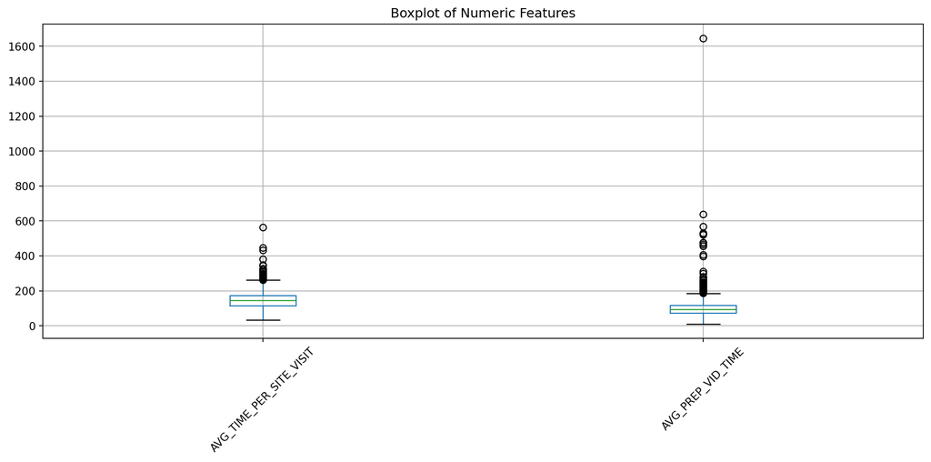

```python
# boxplot of key numeric features
num_cols = ['AVG_TIME_PER_SITE_VISIT', 'AVG_PREP_VID_TIME']

plt.figure(figsize = (12, 6))
chef_df[num_cols].boxplot()

# title and layout
plt.title(label = 'Boxplot of Numeric Features')
plt.xticks(rotation = 45)
plt.tight_layout()
plt.show()
```

#### **EDA Conclusion**

> The dataset has 1,946 customers x 18 variables with no missing values. `TOTAL_MEALS_ORDERED` and `REVENUE` are right-skewed. Per the data dictionary, `LARGEST_ORDER_SIZE` actually represents average meals per order, so it should be renamed to `AVG_ORDER_SIZE`. The boxplot reveals extreme outliers in `AVG_PREP_VID_TIME` and `AVG_TIME_PER_SITE_VISIT`, which will be handled via IQR-based imputation.

## **Data Preparation**

### **Column Renaming**

```python
# rename per data dictionary (see EDA conclusion for rationale)
chef_df.rename(columns = {'AVG_MEAN_RATING'    : 'AVG_MEAL_RATING',
                          'LARGEST_ORDER_SIZE'  : 'AVG_ORDER_SIZE'},
               inplace = True)
```

### **Outlier Imputation - Median**

> Values beyond 1.5*IQR are replaced with the column median (Tukey, 1977). This retains full sample size while neutralizing extreme observations to get the distribution as close as possible to a normally distributed.

```python
columns_to_impute = ['AVG_TIME_PER_SITE_VISIT',
                     'AVG_PREP_VID_TIME']

print("\n--- Before IQR Imputation ---")
for col in columns_to_impute:
    print(f"{col:30s} | Max: {chef_df[col].max():10.2f} | Mean: {chef_df[col].mean():10.2f} | Median: {chef_df[col].median():10.2f}")

for col in columns_to_impute:
    chef_df = impute_outliers_iqr(chef_df, col)

print("\n--- After IQR Imputation ---")
for col in columns_to_impute:
    print(f"{col:30s} | Max: {chef_df[col].max():10.2f} | Mean: {chef_df[col].mean():10.2f} | Median: {chef_df[col].median():10.2f}")
```

```
--- Before IQR Imputation ---
AVG_TIME_PER_SITE_VISIT        | Max:     564.20 | Mean:     150.56 | Median:     145.60
AVG_PREP_VID_TIME              | Max:    1645.60 | Mean:      99.60 | Median:      94.16

--- After IQR Imputation ---
AVG_TIME_PER_SITE_VISIT        | Max:     262.20 | Mean:     146.14 | Median:     145.60
AVG_PREP_VID_TIME              | Max:     184.94 | Mean:      91.77 | Median:      94.14
```

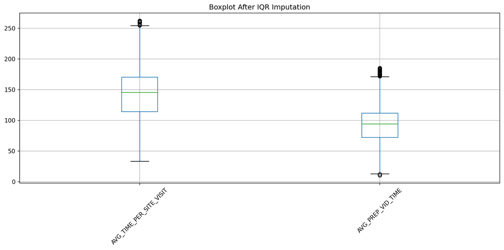

```python
# boxplot after imputation
plt.figure(figsize = (12, 6))
chef_df[columns_to_impute].boxplot()

# title and layout
plt.title(label = 'Boxplot After IQR Imputation')
plt.xticks(rotation = 45)
plt.tight_layout()
plt.show()
```

> After imputation, both features show much tighter distributions. The outliers that were isolated point now fall more cloelly to the Quartile 3 and 1.

### **Email Domain Segmentation**

> Domains grouped per the case study’s marketing classification: **Professional** (corporate), **Personal** (consumer providers), **Junk** (low-deliverability domains).

```python
# extracting email domain from the EMAIL column
chef_df['EMAIL_DOMAIN'] = chef_df['EMAIL'].str.extract(r'@(.+)$')[0]


professional_domains = [
    'mmm.com', 'amex.com', 'apple.com', 'boeing.com', 'caterpillar.com',
    'chevron.com', 'cisco.com', 'cocacola.com', 'disney.com', 'dupont.com',
    'exxon.com', 'ge.org', 'goldmansacs.com', 'homedepot.com', 'ibm.com',
    'intel.com', 'jnj.com', 'jpmorgan.com', 'mcdonalds.com', 'merck.com',
    'microsoft.com', 'nike.com', 'pfizer.com', 'pg.com', 'travelers.com',
    'unitedtech.com', 'unitedhealth.com', 'verizon.com', 'visa.com', 'walmart.com'
]

personal_domains = ['gmail.com', 'sparkplug.com', '360.com', 'protonmail.com']

junk_domains = ['me.com', 'aol.com', 'hotmail.com', 'live.com',
                'msn.com', 'passport.com', 'yahoo.com']


# categorizing each customer into one of three domain groups
chef_df['DOMAIN_TYPE'] = chef_df['EMAIL_DOMAIN'].apply(
    lambda domain: 'Personal' if domain in personal_domains
    else ('Professional' if domain in professional_domains
    else 'Junk'))
```

## **Feature Engineering**

```python
# 1. INTERACTION TERMS
# ENGAGEMENT INDEX - weighted composite normalized to 0-1
chef_df['ENGAGEMENT_INDEX'] = (
    (chef_df['AVG_TIME_PER_SITE_VISIT'] / chef_df['AVG_TIME_PER_SITE_VISIT'].max()) * 0.4 +
    (chef_df['AVG_PREP_VID_TIME']       / chef_df['AVG_PREP_VID_TIME'].max())       * 0.3 +
    (chef_df['TOTAL_PHOTOS_VIEWED']     / chef_df['TOTAL_PHOTOS_VIEWED'].max())     * 0.3
)

chef_df['TOTAL_LOGINS']       = chef_df['PC_LOGINS'] + chef_df['MOBILE_LOGINS']
chef_df['ENGAGEMENT_X_MEALS'] = chef_df['ENGAGEMENT_INDEX'] * chef_df['TOTAL_MEALS_ORDERED']
chef_df['MEALS_X_RATING']     = chef_df['TOTAL_MEALS_ORDERED'] * chef_df['AVG_MEAL_RATING']
chef_df['SITE_X_RATING']      = chef_df['AVG_TIME_PER_SITE_VISIT'] * chef_df['AVG_MEAL_RATING']

# 2. LOG TRANSFORMS - compress right-skewed features
chef_df['LOG_AVG_VID_TIME'] = np.log1p(chef_df['AVG_PREP_VID_TIME'])
chef_df['LOG_AVG_TIME']    = np.log1p(chef_df['AVG_TIME_PER_SITE_VISIT'])
chef_df['LOG_TOTAL_MEALS'] = np.log1p(chef_df['TOTAL_MEALS_ORDERED'])

# 3. RATIO FEATURES - normalize counts by activity level (+1 prevents div by zero)
chef_df['UNIQUE_MEAL_RATIO']   = chef_df['UNIQUE_MEALS_PURCH']           / (chef_df['TOTAL_MEALS_ORDERED'] + 1)
chef_df['MEALS_PER_LOGIN']     = chef_df['TOTAL_MEALS_ORDERED']          / (chef_df['TOTAL_LOGINS'] + 1)
chef_df['LARGEST_ORDER_RATIO'] = chef_df['AVG_ORDER_SIZE']               / (chef_df['TOTAL_MEALS_ORDERED'] + 1)
chef_df['SERVICE_RATIO']       = chef_df['CONTACTS_W_CUSTOMER_SERVICE']  / (chef_df['TOTAL_MEALS_ORDERED'] + 1)

# 4. LOG-TRANSFORMED TARGET
chef_df['log_REVENUE'] = np.log1p(chef_df['REVENUE'])
```

#### **Rationale**

**Interaction Terms:**

> **`ENGAGEMENT_INDEX`**: Weighted composite (site time 40%, prep video 30%, photos 30%) normalized to 0-1. Site time receives the highest weight (40%) because active browsing behavior, clicking through recipes, exploring meal options , indicates deliberate purchase intent and decision-making. Prep video watching (30%) captures learning engagement but is more passive; customers may watch videos without converting to orders. Photo viewing (30%) represents visual product engagement. All three components are normalized by their maximum values to prevent scale dominance, creating a balanced 0-1 index that captures overall digital engagement across multiple touchpoints.

> **`TOTAL_LOGINS`**: Sum of PC and mobile logins, capturing total platform access frequency regardless of device. This provides a device-agnostic measure of customer activity and serves as a denominator for ratio features.

> **`ENGAGEMENT_X_MEALS`**: Multiplicative interaction between `ENGAGEMENT_INDEX` and `TOTAL_MEALS_ORDERED`. This feature captures the synergy between digital engagement and purchasing behavior. A customer who browses heavily but rarely converts (high engagement, low meals) scores low; similarly, a customer who orders frequently but doesn’t engage with content (low engagement, high meals) also scores low. Only customers who are *both* digitally active *and* frequent purchasers score high.

> **`MEALS_X_RATING`**: Interaction between `TOTAL_MEALS_ORDERED` and `AVG_MEAL_RATING`. Captures customers who both order frequently and rate highly, loyal, satisfied customers who demonstrate their approval through continued purchasing. A customer with 100 meals at 4.5 stars is fundamentally different from one with 20 meals at 4.5 stars, even though their ratings are identical.

> **`SITE_X_RATING`**: Interaction between `AVG_TIME_PER_SITE_VISIT` and `AVG_MEAL_RATING`. Identifies customers who spend significant time researching *and* end up satisfied with their choices. This interaction isolates engaged browsers who convert successfully, distinguishing them from browsers with low satisfaction or high-satisfaction customers who don’t engage deeply with content.

**Log Transformations:**

> **`LOG_AVG_VID_TIME`**, **`LOG_AVG_TIME`**, **`LOG_TOTAL_MEALS`**: Applied using `np.log1p()` (log of 1 + x) to compress right-skewed distributions. Log transformation pulls outliers closer to the center, reduces heteroscedasticity (non-constant variance), and makes relationships more linear. `log1p` is used instead of raw `log` to handle zero values safely (log(0) is undefined, but log(1 + 0) = 0). Tree-based models don’t require this assumption, but including both raw and log versions gives the model flexibility to learn which scale is more predictive.

**Ratio Features (Normalization by Activity Level):**

> **`UNIQUE_MEAL_RATIO`**: `UNIQUE_MEALS_PURCH / (TOTAL_MEALS_ORDERED + 1)`. Measures recipe variety preference. A high ratio (close to 1) indicates a customer who tries many different recipes; a low ratio indicates repeat ordering of favorites. This captures purchase diversity, which may correlate with engagement or menu satisfaction. The `+1` prevents division by zero for edge cases.

> **`MEALS_PER_LOGIN`**: `TOTAL_MEALS_ORDERED / (TOTAL_LOGINS + 1)`. Measures conversion efficiency. A high value means the customer orders multiple meals per login (efficient converter); a low value suggests browsing without conversion (window-shopping behavior). This ratio normalizes meal counts by platform access frequency, isolating purchase propensity independent of overall activity level.

> **`LARGEST_ORDER_RATIO`**: `AVG_ORDER_SIZE / (TOTAL_MEALS_ORDERED + 1)`. Captures ordering behavior pattern. A high ratio indicates the customer orders in large batches (fewer, bigger orders); a low ratio indicates frequent small orders. This may correlate with subscription behavior (weekly plans encourage larger, regular orders) or household size. Normalizing by total meals prevents this from simply duplicating the `AVG_ORDER_SIZE` signal.

> **`SERVICE_RATIO`**: `CONTACTS_W_CUSTOMER_SERVICE / (TOTAL_MEALS_ORDERED + 1)`. Measures support contact rate per meal ordered. A high ratio may indicate problematic delivery, quality issues, or high-maintenance customers.

**Target Transformation:**

> **`log_REVENUE`**: `np.log1p(REVENUE)` compresses the long right tail of the revenue distribution (raw REVENUE is heavily right-skewed). This transformation reframes the prediction task in percentage terms rather than absolute dollar terms, the model learns to predict multiplicative changes rather than additive ones. A customer moving from $1,000 to $2,000 (+100%) is treated similarly to a customer moving from $2,000 to $4,000 (+100%), even though the dollar increase differs. Both raw `REVENUE` and `log_REVENUE` are compared across all candidate models (14 model-target combinations total) so the final choice is data-driven rather than assumed. Predictions are converted back to dollars via `expm1()` (the inverse of `log1p()`) for interpretation.

### **Categorical Encoding**

> This aims at enconding the categorical variables into separate numerical variables using the **pd.get_dummies()** function. In this case below, the `DOMAIN_TYPE` column (created from the `EMAIL_DOMAIN`) was used for making that transformation.

```python
# one-hot encode domain type
domain_encoded = pd.get_dummies(chef_df[['DOMAIN_TYPE']],
                                prefix = ['domain'],
                                dtype  = int)

chef_prep = chef_df.join(domain_encoded)

# drop non-numeric / intermediate columns
cols_to_drop = ['NAME', 'EMAIL', 'EMAIL_DOMAIN', 'DOMAIN_TYPE',
                'TOTAL_LOGINS']

chef_prep = chef_prep.drop(columns = cols_to_drop)
```

### **Defining Feature Sets**

```python
# full feature set (everything except targets)
x_all = chef_prep.drop(labels = ['REVENUE', 'log_REVENUE'], axis = 1)

# behavioral features only
x_behavioral = chef_prep[['TOTAL_MEALS_ORDERED', 'UNIQUE_MEALS_PURCH',
                          'CONTACTS_W_CUSTOMER_SERVICE', 'AVG_TIME_PER_SITE_VISIT',
                          'AVG_PREP_VID_TIME', 'TOTAL_PHOTOS_VIEWED']]

# curated set: original + engineered features (excludes domain dummies)
x_selected = chef_prep[[
    'ENGAGEMENT_X_MEALS',
    'CONTACTS_W_CUSTOMER_SERVICE',
    'UNIQUE_MEALS_PURCH',
    'AVG_TIME_PER_SITE_VISIT',
    'AVG_MEAL_RATING',
    'AVG_PREP_VID_TIME',
    'TOTAL_MEALS_ORDERED',
    'TOTAL_PHOTOS_VIEWED',
    'ENGAGEMENT_INDEX',
    'LOG_AVG_VID_TIME',
    'LOG_AVG_TIME',
    'UNIQUE_MEAL_RATIO',
    'MEALS_X_RATING',
    'MEALS_PER_LOGIN',
    'LOG_TOTAL_MEALS',
    'SITE_X_RATING',
    'LARGEST_ORDER_RATIO',
    'SERVICE_RATIO'
]]

# targets
y_revenue     = chef_prep['REVENUE']
y_log_revenue = chef_prep['log_REVENUE']
```

## **Task 1: Customer Segmentation Analysis**

**Question:** What customer segments can be identified from email domains for targeted marketing?

#### **Revenue by Domain Type**

```python
# distribution of domain types
domain_dist = chef_df['DOMAIN_TYPE'].value_counts()
print(domain_dist)
```

```
DOMAIN_TYPE
Professional    696
Junk            663
Personal        587
Name: count, dtype: int64
```

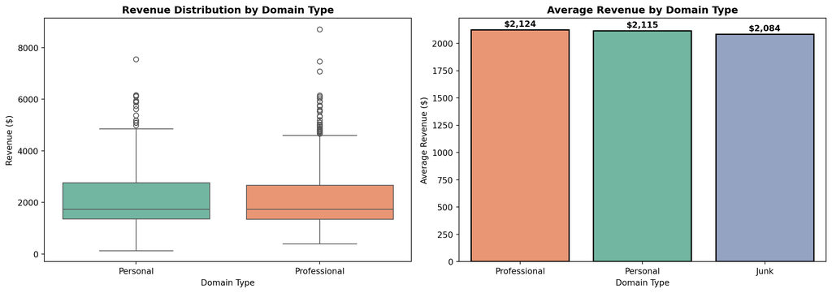

```python
# define colors for each domain type
domain_colors = {'Personal': '#66c2a5', 'Professional': '#fc8d62', 'Junk': '#8da0cb'}

# create side-by-side box plot and bar chart
fig, axes = plt.subplots(1, 2, figsize = (14, 5))

# box plot
sns.boxplot(data    = chef_df,
            x       = 'DOMAIN_TYPE',
            y       = 'REVENUE',
            ax      = axes[0],
            palette = domain_colors,
            order   = ['Personal', 'Professional'])
axes[0].set_xlabel('Domain Type')
axes[0].set_ylabel('Revenue ($)')
axes[0].set_title('Revenue Distribution by Domain Type',
                  fontsize = 12, fontweight = 'bold')

# avg revenue bar chart
avg_revenue = chef_df.groupby('DOMAIN_TYPE')['REVENUE'].mean().sort_values(ascending = False)
colors = [domain_colors[dt] for dt in avg_revenue.index]
sns.barplot(x       = avg_revenue.index,
            y       = avg_revenue.values,
            ax      = axes[1],
            palette = colors,
            edgecolor = 'black',
            linewidth = 1.5)
axes[1].set_xlabel('Domain Type')
axes[1].set_ylabel('Average Revenue ($)')
axes[1].set_title('Average Revenue by Domain Type',
                  fontsize = 12, fontweight = 'bold')

for i, v in enumerate(avg_revenue.values):
    axes[1].text(i, v + 30, f'${v:,.0f}',
                 ha = 'center', fontsize = 10, fontweight = 'bold')

plt.tight_layout()
plt.show()
```

#### **Statistical Test (ANOVA): Revenue by Domain Type**

```python
# one-way ANOVA: revenue across domain types
domain_groups = [chef_df[chef_df['DOMAIN_TYPE'] == domain]['REVENUE']
                 for domain in ['Personal', 'Professional', 'Junk']]

f_stat, p_value = stats.f_oneway(*domain_groups)

print(f"""
One-Way ANOVA: Revenue by Domain Type
--------------------------------------
F-statistic   : {f_stat:.4f}
P-value       : {p_value:.4f}
Result: {'NOT statistically significant (p > 0.05)' if p_value > 0.05 else 'Statistically significant (p <= 0.05)'}
""")
```

```
One-Way ANOVA: Revenue by Domain Type
--------------------------------------
F-statistic   : 0.2281
P-value       : 0.7961
Result: NOT statistically significant (p > 0.05)
```

> The ANOVA confirms no significant difference in revenue across domain types (p = 0.80). Domain classification may still matter for email deliverability, but it should not be used for revenue-based targeting. Behavioral segmentation based on ordering frequency and engagement is far more effective for identifying high-value customers (Kumar et al., 2010; Gupta & Zeithaml, 2006).

## **Task 2: Linear Regression (Behavioral Factors)**

**Question:** Which behavioral factor is the most important in predicting revenue?

#### **Model Development**

```python
# behavioral features only (isolate individual drivers before adding engineered features)
x_data = x_behavioral
y_data = y_revenue

# train-test split
x_train, x_test, y_train, y_test = train_test_split(x_data,
                                                     y_data,
                                                     test_size    = 0.35,
                                                     random_state = 702)

# fit OLS
behavioral_model = sklearn.linear_model.LinearRegression()
behavioral_model_fit = behavioral_model.fit(x_train, y_train)

train_score = round(behavioral_model.score(x_train, y_train), ndigits = 4)
test_score  = round(behavioral_model.score(x_test , y_test) , ndigits = 4)
gap         = round(abs(train_score - test_score)            , ndigits = 4)

print(f"""
Behavioral Features Linear Regression
--------------------------------------
Training R-squared : {train_score}
Testing R-squared  : {test_score}
Train-Test Gap     : {gap}
""")
```

```
Behavioral Features Linear Regression
--------------------------------------
Training R-squared : 0.5446
Testing R-squared  : 0.5986
Train-Test Gap     : 0.054
```

#### **Coefficient Analysis with Statistical Significance**

```python
# statsmodels OLS for p-values and t-statistics (sklearn doesn't provide these)
x_ols     = sm.add_constant(x_train)
ols_model = sm.OLS(y_train, x_ols).fit()
print(ols_model.summary())
```

```
                            OLS Regression Results
==============================================================================
Dep. Variable:                REVENUE   R-squared:                       0.545
Model:                            OLS   Adj. R-squared:                  0.542
Method:                 Least Squares   F-statistic:                     250.6
Date:                Sun, 22 Feb 2026   Prob (F-statistic):          1.13e-210
Time:                        10:25:34   Log-Likelihood:                -10168.
No. Observations:                1264   AIC:                         2.035e+04
Df Residuals:                    1257   BIC:                         2.039e+04
Df Model:                           6
Covariance Type:            nonrobust
===============================================================================================
                                  coef    std err          t      P>|t|      [0.025      0.975]
-----------------------------------------------------------------------------------------------
const                        -751.3363    125.856     -5.970      0.000    -998.247    -504.425
TOTAL_MEALS_ORDERED             8.2867      0.442     18.733      0.000       7.419       9.154
UNIQUE_MEALS_PURCH             47.5520      9.468      5.022      0.000      28.977      66.127
CONTACTS_W_CUSTOMER_SERVICE    88.1595      8.841      9.971      0.000      70.814     105.505
AVG_TIME_PER_SITE_VISIT         8.9821      0.602     14.919      0.000       7.801      10.163
AVG_PREP_VID_TIME               0.2454      0.693      0.354      0.723      -1.113       1.604
TOTAL_PHOTOS_VIEWED             1.1767      0.134      8.752      0.000       0.913       1.440
==============================================================================
Omnibus:                      493.359   Durbin-Watson:                   2.107
Prob(Omnibus):                  0.000   Jarque-Bera (JB):             3917.356
Skew:                           1.597   Prob(JB):                         0.00
Kurtosis:                      11.011   Cond. No.                     1.52e+03
==============================================================================

Notes:
[1] Standard Errors assume that the covariance matrix of the errors is correctly specified.
[2] The condition number is large, 1.52e+03. This might indicate that there are
strong multicollinearity or other numerical problems.
```

> `TOTAL_MEALS_ORDERED` is the strongest behavioral predictor (+$8.29/meal, t = 18.73, p < 0.001). `CONTACTS_W_CUSTOMER_SERVICE` (+$88.16, p < 0.001) likely proxies for overall platform engagement rather than complaints alone. `AVG_TIME_PER_SITE_VISIT` (+$8.98, p < 0.001) and `UNIQUE_MEALS_PURCH` (+$47.55, p < 0.001) are also significant, browsing time and recipe variety both drive revenue.

> `AVG_PREP_VID_TIME` is the only non-significant feature (+$0.25, p = 0.723), which suggests that prep videos don’t directly drive spending on their own but may work better as part of composite engagement metrics.

#### **Feature Correlation Analysis**

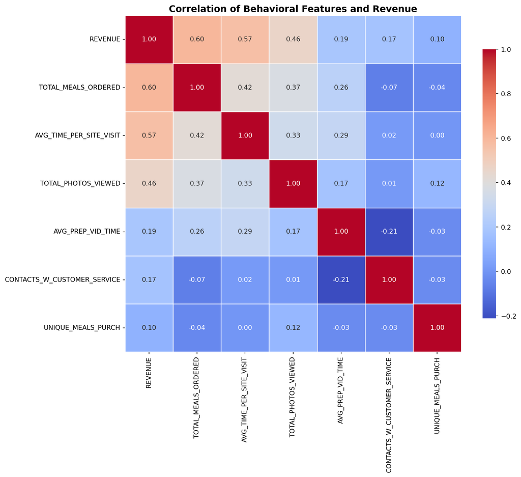

```python
# correlation matrix: behavioral features + revenue
corr_df = pd.concat([x_behavioral, y_revenue.rename("REVENUE")], axis=1).corr()

# sort by correlation with REVENUE (descending)
order = corr_df["REVENUE"].sort_values(ascending=False).index
corr_df = corr_df.loc[order, order]

# heatmap of correlations
plt.figure(figsize=(12, 10))
sns.heatmap(
    data=corr_df,
    annot=True,
    fmt=".2f",
    cmap="coolwarm",
    square=True,
    cbar_kws={"shrink": 0.8},
    linewidths=0.5,
)
plt.title(
    label="Correlation of Behavioral Features and Revenue",
    fontsize=14,
    fontweight="bold",
)
plt.tight_layout()
plt.show()
```

## **Task 3: Final Model Selection**

> Seven model types are evaluated on both raw `REVENUE` and `log(REVENUE + 1)` using the same 65/35 split (random_state = 702).

> Regularized models and KNN use `StandardScaler`; tree-based models and OLS use raw features. A model is considered stable if its train-test gap <= 0.05. The best model is the stable candidate with the highest Test R-squared.

### **Train-Test Split and Scaling**

```python
# curated feature set for model comparison
x_data = x_selected
y_data = y_revenue

# same split as Task 2 for comparability
x_train, x_test, y_train, y_test = train_test_split(x_data,
                                                     y_data,
                                                     test_size    = 0.35,
                                                     random_state = 702)

# log targets from same split indices
y_train_log = np.log1p(y_train)
y_test_log  = np.log1p(y_test)

# scale for regularized models and KNN
scaler         = StandardScaler()
x_train_scaled = scaler.fit_transform(x_train)
x_test_scaled  = scaler.transform(x_test)
```

### **Candidate Models (All Permitted Types)**

> The dictionary `models` below represents all the 7 models appended together so I could compare the output of them at the end, and see which would give the highest r-squared (while preserving the < 0.05 train-test gap). The parameters used in each model was a combination of trial and error to see the ones that would result in the best outcome for each model.

```python
# candidate models - 'scaled' flag selects StandardScaler features automatically
models = {
    'OLS Linear Regression': {
        'model': sklearn.linear_model.LinearRegression(),
        'scaled': False
    },
    'Lasso Regression': {
        'model': Lasso(alpha=230, random_state=702, max_iter=10000),
        'scaled': True
    },
    'Ridge Regression': {
        'model': Ridge(alpha=1950, random_state=702),
        'scaled': True
    },
    'Elastic Net': {
        'model': SGDRegressor(loss='squared_error', penalty='elasticnet',
                              alpha=5.0, l1_ratio=0.7, random_state=702,
                              max_iter=10000, tol=1e-3),
        'scaled': True
    },
    'K-Nearest Neighbors': {
        'model': KNeighborsRegressor(n_neighbors=17, weights='uniform'),
        'scaled': True
    },
    'Random Forest': {
        'model': RandomForestRegressor(n_estimators=300, min_samples_split=10,
                                       min_samples_leaf=25, max_depth=10,
                                       bootstrap=True, random_state=702, n_jobs=-1),
        'scaled': False
    },
    'Gradient Boosting': {
        'model': GradientBoostingRegressor(n_estimators=150, learning_rate=0.1,
                                           max_depth=2, min_samples_leaf=60,
                                           random_state=702),
        'scaled': False
    }
}

# targets to compare
targets = {
    'REVENUE':     {'train': y_train,     'test': y_test,     'is_log': False},
    'log_REVENUE': {'train': y_train_log, 'test': y_test_log, 'is_log': True}
}

# train and evaluate all model-target combinations
candidate_results = []
fitted_models     = {}

for target_name, t in targets.items():
    for model_name, cfg in models.items():
        m = clone(cfg['model'])

        xt_train = x_train_scaled if cfg['scaled'] else x_train
        xt_test  = x_test_scaled  if cfg['scaled'] else x_test

        m.fit(xt_train, t['train'])

        train_r2 = m.score(xt_train, t['train'])
        test_r2  = m.score(xt_test,  t['test'])

        candidate_results.append({
            'Target'         : target_name,
            'Model'          : model_name,
            'Train R-squared': round(train_r2, 4),
            'Test R-squared' : round(test_r2, 4)
        })

        fitted_models[(target_name, model_name)] = m
```

#### **Model Comparison**

```python
# comparison table with stability flag (gap <= 0.05)
model_comparison = pd.DataFrame(candidate_results)
model_comparison['Gap']    = round(abs(model_comparison['Train R-squared'] - model_comparison['Test R-squared']), 4)
model_comparison['Stable'] = model_comparison['Gap'].apply(lambda x: 'Yes' if x <= 0.05 else 'No')

model_comparison = model_comparison.sort_values('Test R-squared', ascending = False)
display(model_comparison.reset_index(drop = True))

# best stable model
stable_models = model_comparison[model_comparison['Stable'] == 'Yes']
best_model    = stable_models.iloc[0]

print(f"""
Best Stable Model: {best_model['Model']} (Target: {best_model['Target']})
--------------------------------------
Training R-squared : {best_model['Train R-squared']:.4f}
Testing R-squared  : {best_model['Test R-squared']:.4f}
Train-Test Gap     : {best_model['Gap']:.4f}
""")
```

|  | Target | Model | Train R-squared | Test R-squared | Gap | Stable |
| --- | --- | --- | --- | --- | --- | --- |
| 0 | log_REVENUE | Gradient Boosting | 0.8415 | 0.8206 | 0.0209 | Yes |
| 1 | log_REVENUE | Random Forest | 0.7967 | 0.7904 | 0.0063 | Yes |
| 2 | REVENUE | Gradient Boosting | 0.8124 | 0.7842 | 0.0282 | Yes |
| 3 | log_REVENUE | K-Nearest Neighbors | 0.7830 | 0.7715 | 0.0115 | Yes |
| 4 | log_REVENUE | OLS Linear Regression | 0.7091 | 0.7382 | 0.0291 | Yes |
| 5 | REVENUE | Random Forest | 0.7342 | 0.7332 | 0.0010 | Yes |
| 6 | REVENUE | K-Nearest Neighbors | 0.7444 | 0.7303 | 0.0141 | Yes |
| 7 | REVENUE | OLS Linear Regression | 0.6406 | 0.6860 | 0.0454 | Yes |
| 8 | log_REVENUE | Ridge Regression | 0.6114 | 0.6557 | 0.0443 | Yes |
| 9 | REVENUE | Elastic Net | 0.5548 | 0.6015 | 0.0467 | Yes |
| 10 | REVENUE | Ridge Regression | 0.5452 | 0.5886 | 0.0434 | Yes |
| 11 | REVENUE | Lasso Regression | 0.4672 | 0.5143 | 0.0471 | Yes |
| 12 | log_REVENUE | Lasso Regression | 0.0000 | -0.0004 | 0.0004 | Yes |
| 13 | log_REVENUE | Elastic Net | -0.0000 | -0.0004 | 0.0004 | Yes |

```
Best Stable Model: Gradient Boosting (Target: log_REVENUE)
--------------------------------------
Training R-squared : 0.8415
Testing R-squared  : 0.8206
Train-Test Gap     : 0.0209
```

> For Gradient Boosting, the log target achieves Test R-squared = 0.82 vs. 0.78 on raw `REVENUE`, with a tighter gap (0.021 vs. 0.028). The log compression helps the ensemble handle the right-skewed revenue distribution more effectively. Predictions are back-transformed to dollars via `expm1` for interpretation.

#### **Best Model Visualization**

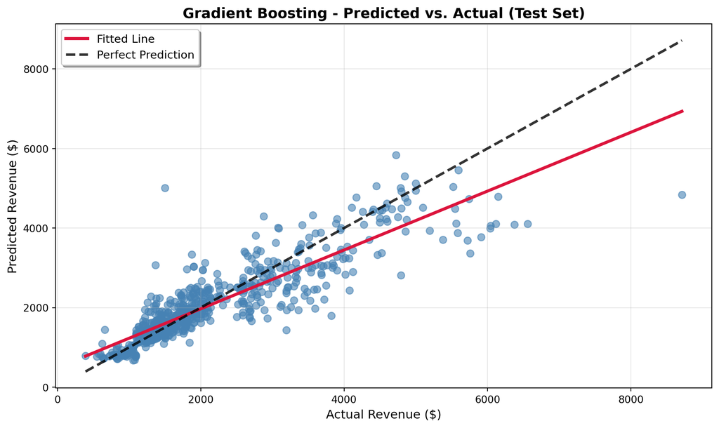

```python
# predict on test set with best model
best_key    = (best_model['Target'], best_model['Model'])
best_fitted = fitted_models[best_key]
best_cfg    = models[best_model['Model']]
xt_test_v   = x_test_scaled if best_cfg['scaled'] else x_test

# back-transform to dollars if log target was used
if best_model['Target'] == 'log_REVENUE':
    y_actual_test = np.expm1(y_test_log)
    y_pred_test   = np.expm1(best_fitted.predict(xt_test_v))
else:
    y_actual_test = y_test
    y_pred_test   = best_fitted.predict(xt_test_v)

# predicted vs actual scatterplot
fig, ax = plt.subplots(1, 1, figsize=(10, 6))

sns.regplot(x           = y_actual_test,
            y           = y_pred_test,
            ax          = ax,
            ci          = None,
            scatter_kws = {'alpha': 0.6, 's': 50, 'color': 'steelblue', 'label': 'Data'},
            line_kws    = {'color': 'crimson', 'lw': 3, 'label': 'Fitted Line'})

min_val = min(y_actual_test.min(), y_pred_test.min())
max_val = max(y_actual_test.max(), y_pred_test.max())
ax.plot([min_val, max_val], [min_val, max_val],
        'k--', lw=2.5, alpha=0.8, label='Perfect Prediction')

ax.set_xlabel('Actual Revenue ($)', fontsize=12)
ax.set_ylabel('Predicted Revenue ($)', fontsize=12)
ax.set_title(f'{best_model["Model"]} - Predicted vs. Actual (Test Set)',
             fontsize=14, fontweight='bold')
ax.legend(loc='upper left', frameon=True, fancybox=True,
          shadow=True, fontsize=11)
ax.grid(True, alpha=0.3)
plt.tight_layout()
plt.show()
```

> Most points cluster tightly around the 45-degree perfect-prediction line, especially in the $1,000-$3,000 range where most customers fall. At higher revenue levels the model underestimates somewhat - a known artifact of log-target models, where the transformation compresses large values during training. Overall calibration is strong (Test R-squared ~0.82).

#### **Best Model Feature Importance**

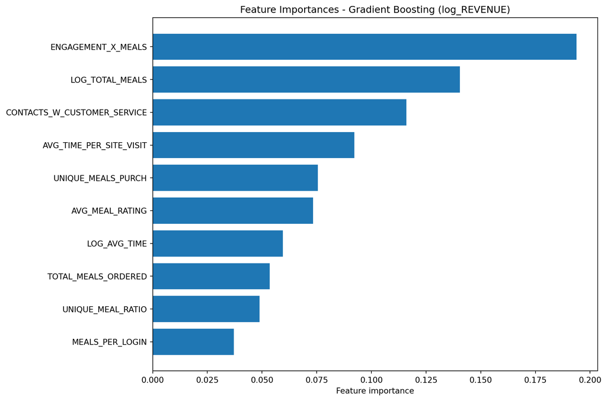

```python
# top 10 features by importance
plot_feature_importances(
    model  = best_fitted,
    train  = x_train,
    title  = f"Feature Importances - {best_model['Model']} ({best_model['Target']})",
    export = False,
    top_n  = 10)
```

## **Conclusion**

> The final model is a **Gradient Boosting Regressor** (150 estimators, learning rate 0.1, max depth 2, min samples leaf 60) trained on `log(REVENUE + 1)`. Selected from 14 model-target combinations, it achieves the highest stable Test R-squared (~0.82) with a gap of 0.021, well within the 0.05 threshold. The log target outperformed raw REVENUE (Test R-squared = 0.78, gap = 0.028). Predictions are converted back to dollars via `expm1`.

> **Recommendations**: Focus retention campaigns on customers below 40 total meals, where small increases in engagement can shift lifetime value substantially (Reichheld & Sasser, 1990). Invest in engagement content (prep videos, food photography) that feeds the top predictive features. Introduce loyalty tiers at 50/100/150 meals to incentivize progression from growth to premium segments (Uncles et al., 2003).

## **References**

Gupta, S., & Zeithaml, V. (2006). Customer metrics and their impact on financial performance. *Marketing Science, 25*(6), 718-739. https://doi.org/10.1287/mksc.1060.0221

Kumar, V., Aksoy, L., Donkers, B., Venkatesan, R., Wiesel, T., & Tillmanns, S. (2010). Undervalued or overvalued customers: Capturing total customer engagement value. *Journal of Service Research, 13*(3), 297-310. https://doi.org/10.1177/1094670510375602

Reichheld, F. F., & Sasser, W. E. (1990). Zero defections: Quality comes to services. *Harvard Business Review, 68*(5), 105-111.

Tukey, J. W. (1977). *Exploratory data analysis*. Addison-Wesley.

Uncles, M. D., Dowling, G. R., & Hammond, K. (2003). Customer loyalty and customer loyalty programs. *Journal of Consumer Marketing, 20*(4), 294-316. https://doi.org/10.1108/07363760310483676